# Práctica 3 - Módulo 3

Regresión lineal simple y múltiple

Diplomatura en Ciencias Sociales Computacionales y Humanidades Digitales (IDAES-UNSAM).

> Material elaborado originalmente por Carolina Pradier y Guido Weksler

```r
library(tidyverse)
library(tidymodels)
library(viridis)
library(car)
library(performance)
tidymodels_prefer()

options(dplyr.summarise.inform = FALSE)
```

# 1 Introducción

Vamos a seguir trabajando con nuestra base de juguete para construir una regresión lineal múltiple.

```r
base_juguete <- readRDS("./fuentes/eut_juguete.RDS")
#Ruta puede variar base_juguete <- readRDS("./clase3/fuentes/eut_juguete.RDS")
```

# 2 Regresión lineal simple

En la clase anterior habíamos llegado a esta regresión lineal simple, pero notábamos que nuestro modelo tenía problemas para explicar algunos de los valores. Vamos a intentar mejorarlo agregando más información con otras variables.

```r
lm_model <- linear_reg() %>%
  set_mode("regression") %>%
  set_engine("lm")
```

```r
lm_fit <- lm_model %>%
  fit(ingreso_individual ~ horas_trabajo_domestico,
      data = base_juguete)
```

# 3 Regresión lineal múltiple

Antes de empezar, chequeamos multicolinealidad con la función vif() del paquete *car*.

```r
lm_vif <- lm(ingreso_individual ~ . , #Con . indicamos "todas las demás"
               data = base_juguete)

# Calculo vif (variance inflation factor)
vif(lm_vif)
```

```
##                      sexo realiza_trabajo_domestico     horas_trabajo_mercado
##                  2.786822                  1.408604                  3.308256
##   horas_trabajo_domestico             menores_hogar
##                  1.996179                  1.084778
```

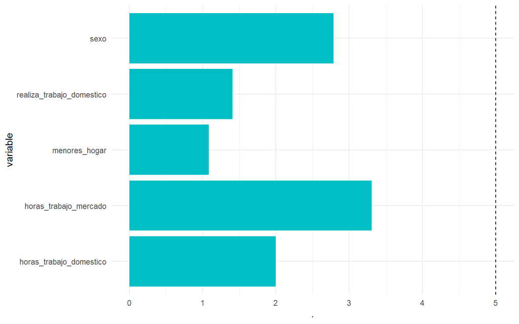

```r
# Lo miro con un plot
vif(lm_vif) %>% data.frame() %>%
  rownames_to_column(var="variable") %>%
  ggplot(aes(x=variable,y=.))+
  geom_col(fill="#00BFC4")+
  geom_hline(yintercept = 5, linetype = "dashed")+
  coord_flip()+
  theme_minimal()
```

En todos los casos los valores son bajos, por lo que podemos incorporar todas las variables que nos parezcan relevantes. Probemos con todas:

```r
lm_fit2 <- lm_model %>%
  fit(formula = ingreso_individual ~ ., #Con "." indicamos "todas las demás"
      data = base_juguete)
```

Notemos cómo tidymodels nos permite aplicar fácilmente el modelo que estamos trabajando (lm_model) a distintas fórmulas. Veamos los coeficientes y la significatividad de las relaciones.

```r
lm_fit2 %>%
  pluck("fit") %>%
  summary()
```

```
##
## Call:
## stats::lm(formula = ingreso_individual ~ ., data = data)
##
## Residuals:
##    Min     1Q Median     3Q    Max
## -34657  -5968   -447   6646  26151
##
## Coefficients:
##                             Estimate Std. Error t value Pr(>|t|)
## (Intercept)                 21344.93    2191.11   9.742  < 2e-16 ***
## sexoMujer                    6812.77    1248.52   5.457 7.13e-08 ***
## realiza_trabajo_domesticoSi  -258.47    1159.42  -0.223    0.824
## horas_trabajo_mercado         613.29      45.03  13.619  < 2e-16 ***
## horas_trabajo_domestico      -229.78      24.20  -9.495  < 2e-16 ***
## menores_hogar               -3298.94     384.71  -8.575  < 2e-16 ***
## ---
## Signif. codes:  0 '***' 0.001 '**' 0.01 '*' 0.05 '.' 0.1 ' ' 1
##
## Residual standard error: 9160 on 594 degrees of freedom
## Multiple R-squared:  0.6323, Adjusted R-squared:  0.6292
## F-statistic: 204.3 on 5 and 594 DF,  p-value: < 2.2e-16
```

La variable realiza_trabajo_domestico no es significativa para analizar el nivel de ingresos. Esto es esperable, dado que la variable *horas_trabajo_domestico* ya incluye la información de la variable *realiza_trabajo_domestico* (valores positivos indican Sí). Por esta razón, se excluye del modelo. Entonces, la ecuación que caracterizaría nuestro modelo es:

$$IngInd = \beta_{0} + \beta_{1}HorasTD +
\beta_{2}HorasM + \beta_{3}Sexo + \beta_{4}Menores +
\epsilon$$

```r
#planteamos el nuevo modelo
lm_fit2 <- lm_model %>%
  fit(ingreso_individual ~ horas_trabajo_domestico +
                           horas_trabajo_mercado +
                           sexo +
                           menores_hogar,
    data = base_juguete)

#y vemos los coeficientes
lm_fit2 %>%
  pluck("fit") %>%
  summary()
```

```
##
## Call:
## stats::lm(formula = ingreso_individual ~ horas_trabajo_domestico +
##     horas_trabajo_mercado + sexo + menores_hogar, data = data)
##
## Residuals:
##    Min     1Q Median     3Q    Max
## -34706  -5944   -348   6573  26125
##
## Coefficients:
##                         Estimate Std. Error t value Pr(>|t|)
## (Intercept)             21159.61    2025.68  10.446  < 2e-16 ***
## horas_trabajo_domestico  -232.17      21.68 -10.710  < 2e-16 ***
## horas_trabajo_mercado     614.08      44.86  13.689  < 2e-16 ***
## sexoMujer                6845.31    1238.97   5.525 4.93e-08 ***
## menores_hogar           -3303.18     383.93  -8.604  < 2e-16 ***
## ---
## Signif. codes:  0 '***' 0.001 '**' 0.01 '*' 0.05 '.' 0.1 ' ' 1
##
## Residual standard error: 9152 on 595 degrees of freedom
## Multiple R-squared:  0.6323, Adjusted R-squared:  0.6298
## F-statistic: 255.8 on 4 and 595 DF,  p-value: < 2.2e-16
```

Noten que mejora el $R^{2}$ **ajustado**.

Veamos la distribución de los residuos:

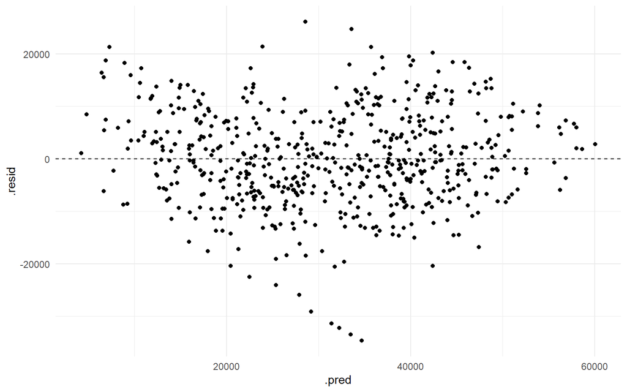

```r
#calculamos
lm_fit2 %>%
  augment(new_data = base_juguete) %>%
  dplyr::select(.resid, .pred) %>%
  #graficamos
  ggplot(aes(x = .pred, y = .resid)) +
    geom_point() +
    theme_minimal() +
    geom_hline(yintercept = 0, linetype = 'dashed')
```

Al observar cómo quedan los residuos, vemos que esta vez el modelo está funcionando mejor que la última vez, la distribución parece ser bastante aleatoria. Veamos si podemos seguir mejorando.

# 4 Agregamos una interacción

Algo que podría ocurrir es que el efecto sobre los ingresos de trabajar de modo remunerado en el mercado sea distinto para las mujeres y los varones: probemos agregar una interacción. Al agregarla, nuestra ecuación pasaría a tomar la forma:

$$IngInd = \beta_{0} + \beta_{1}HorasTD +
\beta_{2}HorasM + \beta_{3}Sexo + \beta_{4}Menores +
\beta_{5}HorasM.Sexo + \epsilon$$

```r
#usamos los ":" para agregar la interacción
lm_fit3 <- lm_model %>%
  fit(ingreso_individual ~ horas_trabajo_domestico +
                         sexo:horas_trabajo_mercado +
                         horas_trabajo_mercado +
                         sexo +
                         menores_hogar,
    data = base_juguete)
```

Veamos los coeficientes:

```r
lm_fit3 %>%
  pluck("fit") %>%
  summary()
```

```
##
## Call:
## stats::lm(formula = ingreso_individual ~ horas_trabajo_domestico +
##     sexo:horas_trabajo_mercado + horas_trabajo_mercado + sexo +
##     menores_hogar, data = data)
##
## Residuals:
##    Min     1Q Median     3Q    Max
## -33875  -5728    -59   5936  27325
##
## Coefficients:
##                                 Estimate Std. Error t value Pr(>|t|)
## (Intercept)                     13925.31    2781.00   5.007 7.29e-07 ***
## horas_trabajo_domestico          -245.11      21.72 -11.285  < 2e-16 ***
## horas_trabajo_mercado             801.67      66.86  11.991  < 2e-16 ***
## sexoMujer                       16334.97    2810.88   5.811 1.01e-08 ***
## menores_hogar                   -3206.63     380.66  -8.424 2.75e-16 ***
## sexoMujer:horas_trabajo_mercado  -317.57      84.65  -3.751 0.000193 ***
## ---
## Signif. codes:  0 '***' 0.001 '**' 0.01 '*' 0.05 '.' 0.1 ' ' 1
##
## Residual standard error: 9054 on 594 degrees of freedom
## Multiple R-squared:  0.6408, Adjusted R-squared:  0.6378
## F-statistic: 211.9 on 5 and 594 DF,  p-value: < 2.2e-16
```

No sólo es significativo el coeficiente de la interacción, sino que además mejoró el $R^{2}$ ajustado.

# 5 Transformar variables en workflows (feature engineering)

El herramental de tidymodels nos permite aplicar distintas transformaciones sobre nuestros datos antes de estimar los coeficientes. La lógica de tidymodels nos permite separar este paso de aquel de especificación del modelo.

Una sintaxis más general para los pasos que aplicamos anteriormente es usar un *workflow.* Es decir, dentro de un workflow, especificamos primero el modelo, luego la fórmula o “receta” de las transformaciones que vamos a hacer a las variables, finalmente estimamos. La gracia de hacer estos pasos por separado es que cada uno es una etapa del proceso de modelado, que merece su propio proceso y que, como vamos a ver, podemos querer combinar de distintas maneras con los otros pasos.

Podemos consultar la presentación de Tidymodels a modo de *cheatsheet* de cómo funcionan los workflows.

Primero agregamos un modelo:

```r
lm_wflow <- workflow() %>%
  add_model(lm_model)
```

Luego agregamos la fórmula:

```r
lm_wflow <- lm_wflow %>%
  add_formula(ingreso_individual ~ horas_trabajo_domestico +
                                   sexo:horas_trabajo_mercado +
                                   horas_trabajo_mercado +
                                   sexo +
                                   menores_hogar
  )
```

Y finalmente estimamos:

```r
lm_fit3 <- lm_wflow %>%
  fit(base_juguete)
```

Veamos los coeficientes y la significatividad. Una forma fácil de hacerlo es directo con `tidy()`.

```r
lm_fit3 %>% tidy()
```

```
## # A tibble: 6 × 5
##   term                              estimate std.error statistic  p.value
##   <chr>                                <dbl>     <dbl>     <dbl>    <dbl>
## 1 (Intercept)                         13925.    2781.       5.01 7.29e- 7
## 2 horas_trabajo_domestico              -245.      21.7    -11.3  6.78e-27
## 3 horas_trabajo_mercado                 802.      66.9     12.0  8.07e-30
## 4 sexoMujer                           16335.    2811.       5.81 1.01e- 8
## 5 menores_hogar                       -3207.     381.      -8.42 2.75e-16
## 6 `sexoMujer:horas_trabajo_mercado`    -318.      84.7     -3.75 1.93e- 4
```

Pero para extraer los resultados completos después de aplicar fit a un workflow usamos la función `extract_fit_engine()`, que nos devuelve el objeto `lm` subyacente.

```r
lm_fit3 %>%
  extract_fit_engine() %>%
  summary() #%>% tidy()
```

```
##
## Call:
## stats::lm(formula = ..y ~ ., data = data)
##
## Residuals:
##    Min     1Q Median     3Q    Max
## -33875  -5728    -59   5936  27325
##
## Coefficients:
##                                   Estimate Std. Error t value Pr(>|t|)
## (Intercept)                       13925.31    2781.00   5.007 7.29e-07 ***
## horas_trabajo_domestico            -245.11      21.72 -11.285  < 2e-16 ***
## horas_trabajo_mercado               801.67      66.86  11.991  < 2e-16 ***
## sexoMujer                         16334.97    2810.88   5.811 1.01e-08 ***
## menores_hogar                     -3206.63     380.66  -8.424 2.75e-16 ***
## `sexoMujer:horas_trabajo_mercado`  -317.57      84.65  -3.751 0.000193 ***
## ---
## Signif. codes:  0 '***' 0.001 '**' 0.01 '*' 0.05 '.' 0.1 ' ' 1
##
## Residual standard error: 9054 on 594 degrees of freedom
## Multiple R-squared:  0.6408, Adjusted R-squared:  0.6378
## F-statistic: 211.9 on 5 and 594 DF,  p-value: < 2.2e-16
```

En vez de una fórmula, para definir los predictores y las **transformaciones** que queremos aplicarles podemos usar *recipe().* A esto lo llamamos “preprocesamiento” (porque lo hacemos antes de estimar).

Las transformaciones se aplican encadenando comandos *step_xxx()* que se aplican sobre grupos de variables definidas según su rol (*all_predictors()*, *all_outcomes(),* etc) o el tipo de variable (*all_numeric()*, *all_nominal()*).

Se genera una receta de preprocesamiento (lm_rec):

```r
#incorporamos la fórmula
lm_rec <- recipe(
    ingreso_individual ~ horas_trabajo_domestico +
                         horas_trabajo_mercado +
                         sexo +
                         menores_hogar,
    data = base_juguete
  ) %>%

  step_mutate(
    menores_hogar = as.character(menores_hogar),
    id="mutate_inicial"
  ) %>%

  #incorporamos transformaciones
  #agrego interacciones entre sexo y todas las variables que empiecen con "horas"
  step_interact(
    ~sexo:starts_with("horas"),
    id="interacciones"
  ) %>%

  #vuelvo dummy la variable sexo
  step_dummy(sexo, id="dummy") %>%

  #agrupo en niveles que representen al menos el 20% de las observaciones la variable menores_hogar, agrupando a los otros valores en la categoría "otros"
  step_other(menores_hogar, threshold = 0.2, id="other")
```

Le dimos la base de datos, pero no estimamos nada. Solo necesita la base de datos para saber qué variables hay y de qué tipo son. Podemos ver cómo quedarán los datos previo al ajuste del modelo:

```r
lm_rec %>%
  prep() %>% #Aplica transformaciones a las variables (hace la cuenta)
  juice()  #Extrae las variables transformadas (nos muestra el resultado)
```

```
## # A tibble: 600 × 7
##    horas_trabajo_domest…¹ horas_trabajo_mercado menores_hogar ingreso_individual
##                     <dbl>                 <int> <fct>                      <dbl>
##  1                     39                    12 1                          16878
##  2                     31                    40 other                      33150
##  3                      0                    30 0                          59218
##  4                     30                     4 1                          27340
##  5                     54                    15 1                          16352
##  6                     23                    13 1                          21395
##  7                     70                    13 1                          16082
##  8                     66                    10 other                      27204
##  9                     33                    15 2                          37148
## 10                     58                    17 1                          13725
## # ℹ 590 more rows
## # ℹ abbreviated name: ¹horas_trabajo_domestico
## # ℹ 3 more variables: sexoMujer_x_horas_trabajo_domestico <dbl>,
## #   sexoMujer_x_horas_trabajo_mercado <dbl>, sexo_Mujer <dbl>
```

Notemos que ahora la variable cualitativa “menores_hogar” tiene agrupadas a las categorías con pocas observaciones, la dummy “sexo” ya está codificada como “sexo_Mujer”, entre otras transformaciones.

Incorporamos al workflow nuestro nuevo preprocesamiento. Si ya teníamos una fórmula o receta, tenemos que eliminarla para reemplazarla por la nueva.

```r
lm_wflow <- lm_wflow %>%

  #se remueve la fórmula anterior ya que ahora la receta contiene la fórmula
  remove_formula() %>%

  #se añade la receta de preprocesamiento
  add_recipe(lm_rec)
```

Luego aplicamos fit:

```r
lm_fit4 <- lm_wflow %>%
  fit(base_juguete)
```

Miremos la performance de este modelo:

```r
glance(lm_fit4)
```

```
## # A tibble: 1 × 12
##   r.squared adj.r.squared sigma statistic   p.value    df logLik    AIC    BIC
##       <dbl>         <dbl> <dbl>     <dbl>     <dbl> <dbl>  <dbl>  <dbl>  <dbl>
## 1     0.700         0.696 8298.      172. 5.72e-149     8 -6261. 12542. 12586.
## # ℹ 3 more variables: deviance <dbl>, df.residual <int>, nobs <int>
```

Y los coeficientes estimados:

```r
lm_fit4 %>%
  tidy()
```

```
## # A tibble: 9 × 5
##   term                                estimate std.error statistic  p.value
##   <chr>                                  <dbl>     <dbl>     <dbl>    <dbl>
## 1 (Intercept)                          22209.     2768.      8.02  5.56e-15
## 2 horas_trabajo_domestico               -189.       33.0    -5.72  1.72e- 8
## 3 horas_trabajo_mercado                  710.       62.8    11.3   6.05e-27
## 4 menores_hogar1                      -13325.     1006.    -13.2   2.97e-35
## 5 menores_hogar2                      -12769.     1144.    -11.2   2.13e-26
## 6 menores_hogarother                  -14857.     1336.    -11.1   3.30e-26
## 7 sexoMujer_x_horas_trabajo_domestico    -23.3      41.2    -0.566 5.72e- 1
## 8 sexoMujer_x_horas_trabajo_mercado     -298.       82.3    -3.62  3.15e- 4
## 9 sexo_Mujer                           15666.     3022.      5.18  2.99e- 7
```

Vemos que el coeficiente de la interacción entre horas_trabajo_doméstico y sexo es poco significativo, podríamos pensar en sacarlo del modelo.

¿Qué pasó exactamente cuando usamos step_other()?

```r
 lm_fit4 %>%
  extract_recipe(estimated = TRUE) %>%
  tidy(.,id = "other") #id del step (también es posible buscar por número del step (number=4))
```

```
## # A tibble: 3 × 3
##   terms         retained id
##   <chr>         <chr>    <chr>
## 1 menores_hogar 0        other
## 2 menores_hogar 1        other
## 3 menores_hogar 2        other
```

Se agrupó a la variable menores_hogar en 4 categorías: 0, 1, 2 y otros.

¿No nos acordamos qué pasos habíamos seguido? Si no, podemos extraerlo:

```r
lm_fit4 %>%
  extract_recipe(estimated = TRUE)
```

```
## ── Recipe ──────────────────────────────────────────────────────────────────────
```

```
## ── Inputs
```

```
## Number of variables by role
```

```
## outcome:   1
## predictor: 4
```

```
## ── Training information
```

```
## Training data contained 600 data points and no incomplete rows.
```

```
## ── Operations
```

```
## • Variable mutation for: ~as.character(menores_hogar) | Trained
```

```
## • Interactions with: sexo:(horas_trabajo_domestico + horas_trabajo_mercado) |
##   Trained
```

```
## • Dummy variables from: sexo | Trained
```

```
## • Collapsing factor levels for: menores_hogar | Trained
```

# 6 Predicciones

Veamos primero la distribución de los errores y luego la capacidad predictora del modelo

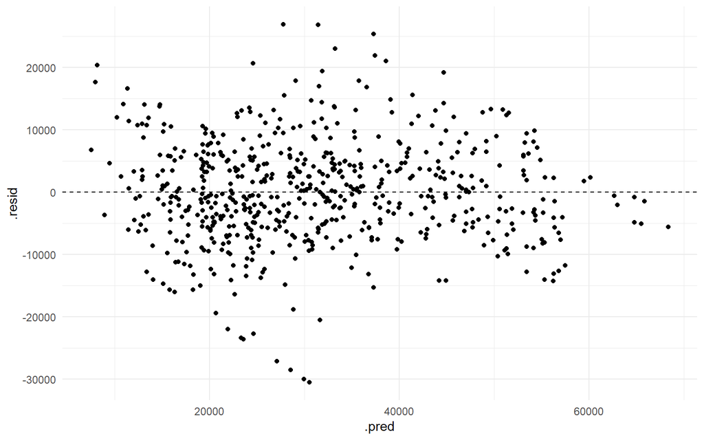

```r
lm_fit4 %>%
augment(new_data = base_juguete) %>%
  mutate(.resid = ingreso_individual - .pred) %>%
  #graficamos
  dplyr::select(.resid, .pred) %>%
  ggplot(aes(x = .pred, y = .resid)) +
    geom_point() +
    theme_minimal() +
    geom_hline(yintercept = 0, linetype = 'dashed')
```

Comparamos el valor real con nuestra predicción:

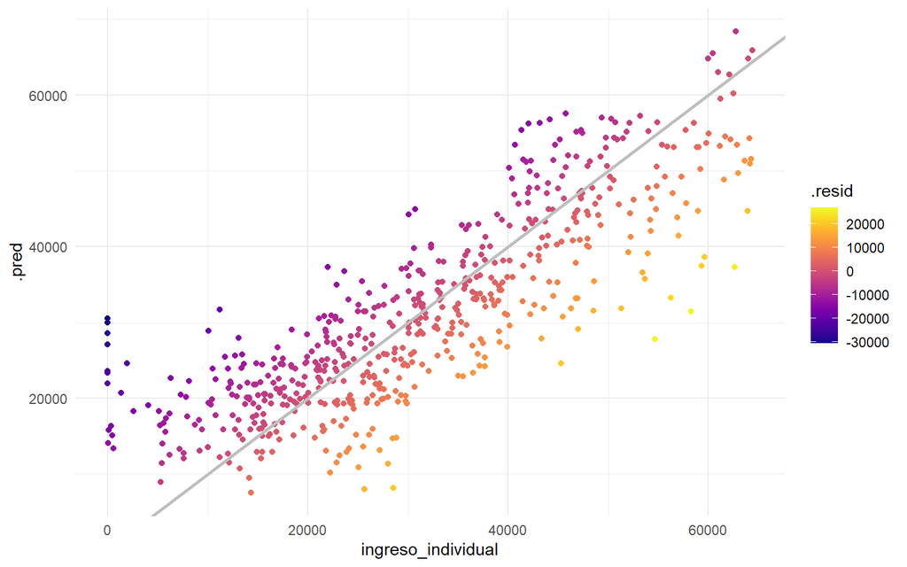

```r
lm_fit4 %>%
augment(new_data = base_juguete) %>%
  mutate(.resid = ingreso_individual - .pred) %>%
  dplyr::select(ingreso_individual, .pred, .resid) %>%
  #graficamos
  ggplot(aes(y = .pred, x = ingreso_individual, color = .resid)) +
    geom_point() +
    theme_minimal()  +
    geom_abline(
      intercept = 0,
      slope = 1,
      linewidth = 1,
      color = "grey"
    ) +
    scale_color_viridis(option = "C")
```

¿Dónde predice peor el modelo? ¿Qué se les ocurre que podría hacerse para mejorarlo? ¿Se les ocurre alguna variable que pueda resultar útil?

# 7 Resumen

Al implementar una regresión lineal múltiple:

- Chequear VIF
- ¿Qué relaciones son significativas?
- Interpretación de los coeficientes de las variables cualitativas
- Transformaciones (codificación, interacciones, etc.)

En tidymodels: usar recipes con workflows. Un workflow podría ser:

```r
# Elijo el modelo
lm_model <- linear_reg() %>%
  set_mode("regression") %>%
  set_engine("lm")

# Armo mi receta (fórmula y transformaciones)
lm_rec <- recipe(
    ingreso_individual ~ sexo,
    data = base_juguete) %>%
  step_dummy(sexo, id="dummy")

# Junto todo en un workflow
lm_wflow <- workflow() %>%
  add_model(lm_model) %>%
  add_recipe(lm_rec)

# Estimo
lm_fit <- lm_wflow %>%
  fit(base_juguete)

# Extraigo resultados
lm_fit %>%
  tidy()
```

```
## # A tibble: 2 × 5
##   term        estimate std.error statistic   p.value
##   <chr>          <dbl>     <dbl>     <dbl>     <dbl>
## 1 (Intercept)   38415.      763.      50.3 3.58e-217
## 2 sexo_Mujer   -14390.     1079.     -13.3 1.08e- 35
```

```r
lm_fit %>%
  augment(base_juguete) %>% select(sexo,ingreso_individual,.pred)
```

```
## # A tibble: 600 × 3
##    sexo  ingreso_individual  .pred
##    <chr>              <dbl>  <dbl>
##  1 Mujer              16878 24025.
##  2 Mujer              33150 24025.
##  3 Mujer              59218 24025.
##  4 Mujer              27340 24025.
##  5 Mujer              16352 24025.
##  6 Mujer              21395 24025.
##  7 Mujer              16082 24025.
##  8 Mujer              27204 24025.
##  9 Mujer              37148 24025.
## 10 Mujer              13725 24025.
## # ℹ 590 more rows
```

# 8 Referencias bibliográficas

- An Introduction to Statistical Learning with applications in R (James, Witten, Hastie y Tibshirani) – 1st and 2nd version
- Tidy Modeling with R (Kuhn y Silge)
- Introduction to Modern Statistics (Çetinkaya-Rundel y Hardin)